# Analysis — identities → metrics + plots

↑ Top

Reads a pre-computed extraction bundle from `<RESULTS_ROOT>/<RUN_NAME>/extraction/` and produces all derived metrics, plots, and the final HTML report.

```
Data source: Control-experiment
 min_frame: 0
 max_frame: 29
 split_frame: 16
 PERI_CORE_RINGS (core_max, peri_min, peri_max): (0.15, 0.25, 0.45)
```

## 0. Load extraction bundle

```
Extraction: 2026-08-17 06:39 UTC (96.4 days ago)  ·  hash d0ca696f365e
Loaded 251 tracks, fluor stack (31, 1040, 1388), phase stack (31, 1040, 1388)
```

## 0.1 Extraction QC

Sanity checks on the extraction the analysis is running against: raw-frame preview, detected cells on frame 0, and frame-quality gating diagnostics. If any of these look off, the downstream metrics do too — re-run extraction with `--force-extract` after adjusting `configs/<run>.yaml::extraction`.

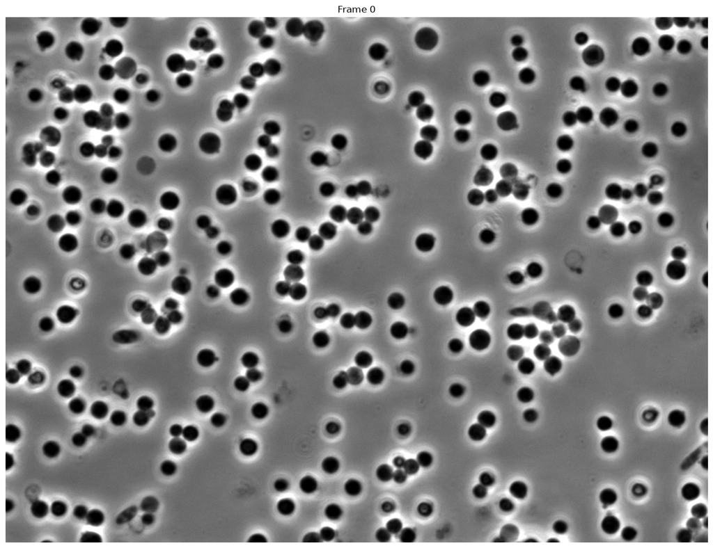

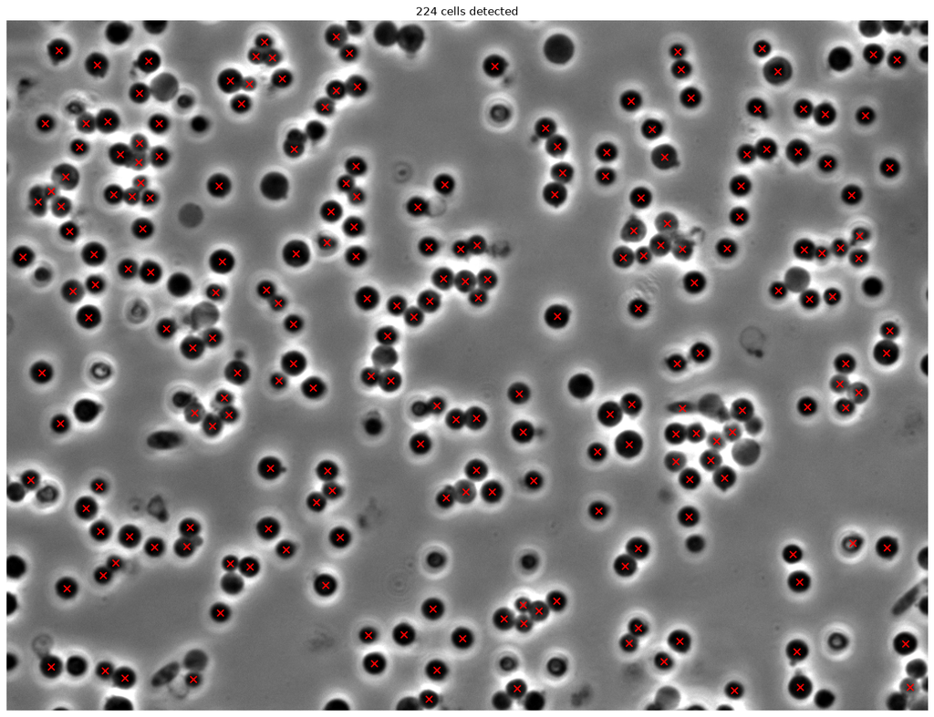

## 1. Statistics and Plots

### 1.1 Cell count

```
Bad frames: none
No frames dropped — all frames passed quality gating.
```

[interactive chart not shown]

```
Gradient starts decreasing after frame: 1
Initial count (at 20.0%): 236
Final count (at 0.0%): 41
Fraction disappeared: 82.6%
50% disappearance at concentration: 1.5%
```

*Source: `tracked_cells.csv`*

### 1.2 Lifetime distribution and disappearance

[output not shown]

[interactive chart not shown]

```
Frame of maximum disappearance: 29
Cells lost at peak: 19
```

*Source: `track_statistics.csv`*

### 1.3 Cell area distribution

Histogram pooled over the first `BASELINE_FRAMES` frames (before medium changes drive swelling). Areas are in µm² after the `PIXEL_SIZE_UM` rescale applied in `add_geometry`. Set `BASELINE_FRAMES = 1` to recover frame-0-only.

[interactive chart not shown]

```
Median area:         3.99 µm²
Median volume:       6.00 µm³
Median surface area: 15.98 µm²
```

*Source: `tracked_cells.csv`*

### 1.4 Cell Volume Diagnostics

Frame-by-frame mean and median cell volume ($\mu\text{m}^3$) across the population.

[interactive chart not shown]

*Source: `tracked_cells.csv`*

### 1.5a Relative swelling dynamics V(t)/V(0) and S(t)/S(0)

Population-averaged relative volume and surface area change over time. Only tracks present at frame 0 are included (initial population with known baseline). Shaded band shows mean +/- SEM. Faint individual traces from a random subset of 20 cells shown for context.

```
Tracks starting at frame 0: 224
```

[interactive chart not shown]

```
Final V(t)/V(0) at frame 30: 1.793 ± 0.119
Final S(t)/S(0) at frame 30: 1.453 ± 0.060
Cells contributing at final frame: 40
```

*Source: `tracked_cells.csv`*

### 1.5b Membrane tension proxy ($\text{Sucrose (\%)} \times R$) vs. relative cell expansion

By Laplace's law ($\gamma \propto \Delta\Pi \cdot R$), the product of external sucrose concentration and cell radius ($\text{Sucrose (\%)} \times R$) serves as a proxy for membrane tension. Plotting tension against relative volume change $[V(t)-V(0)]/V(0)$ and areal strain $[S(t)-S(0)]/S(0)$ reveals two distinct mechanical regimes (Phase 1 and Phase 2 piecewise linear fits), shown both across the entire cohort and split by survival outcome.

[interactive chart not shown]

*Sources: `tracked_cells.csv`, `track_statistics.csv`*

[interactive chart not shown]

*Sources: `tracked_cells.csv`, `track_statistics.csv`*

### 1.6a Osmotic Burst Limits

Sucrose concentration at the moment of cell disappearance (burst) plotted against initial cell volume ($V_0$) and final pre-burst volume ($V_{\text{final}}$) for disappeared tracks.

[interactive chart not shown]

*Sources: `tracked_cells.csv`, `track_statistics.csv`*

### 1.6b Swelling extent vs. initial cell size and survival

**Left:** does the magnitude of swelling depend on initial cell volume? Each dot is one frame-0 track; the x-axis is $V(0)$, and the y-axis is the maximum $V(t)/V(0)$ reached during that track's lifetime. The dashed trendline and shaded band show the smoothed trend computed with a 95% relative weight. **Right:** do cells that disappear (lyse) swell differently from those that survive? Population-averaged $V(t)/V(0)$ curves split by outcome.

**Why disappeared cells show lower median max swelling but higher curves at late frames:** Disappeared cells burst early — many leave by frame 10–15 and had fewer frames to accumulate volume, so their lifetime peak is lower. The right panel shows the opposite at late frames because of survivorship bias: the only disappeared cells still tracked at frames 20+ are the extreme swellers that haven't burst yet. Both views are correct; they measure different things (lifetime peak vs. instantaneous population mean).

A more comparable metric is swelling rate per frame (printed below), which normalizes for lifetime differences.

[interactive chart not shown]

```
Frame-0 cohort: 40 survived, 184 disappeared
Mean initial volume (survived):    6.53 ± 1.81 µm³
Mean initial volume (disappeared): 5.86 ± 2.04 µm³
Median max swelling (survived):    1.979x
Median max swelling (disappeared): 1.854x
Median swelling rate (survived):    0.0316x per frame
Median swelling rate (disappeared): 0.0443x per frame
```

*Source: `tracked_cells.csv`*

### 1.6c Relative swelling $V(t)/V(0)$ vs. normalized lifespan, by fate

Three views: population mean $\pm$ SEM vs. sucrose concentration, lifespan-normalized average split by fate, and sucrose-axis split by fate. Same panel layout as the CV/nNRM dynamics in §3.4a–§3.5a.

[interactive chart not shown]

*Sources: `tracked_cells.csv`, `track_statistics.csv`*

### 1.7a Phase-Contrast Intensity vs. Sucrose Concentration

Correlations of relative phase-contrast intensity $(I_0 - I)/I_0$ versus sucrose concentration, where $I_0$ is the background mean in the ROI and $I$ is the mean intensity within the cell mask. Serves as a proxy for intracellular density and refractive index changes during osmotic shifts. The solid line with markers represents the population mean, and faint individual data points represent all detected cells to illustrate population variance.

[interactive chart not shown]

*Source: `tracked_cells.csv`*

### 1.7b Phase-Contrast Intensity vs. Volume Ratio

Relative phase-contrast intensity $(I_0 - I)/I_0$ plotted against relative cell volume $V(t)/V(0)$ across all tracked detections. Faint individual points show single-cell measurements, while the solid line and shaded band represent the trend computed with a 95% relative weight, illustrating how intracellular optical density decreases as cells swell.

[interactive chart not shown]

*Source: `tracked_cells.csv`*

## 2. Fluorescence Preview

Background-subtracted fluorescence stack, aligned frame-by-frame with the phase-contrast stack. Bad frames already have zeroed label masks from gating.

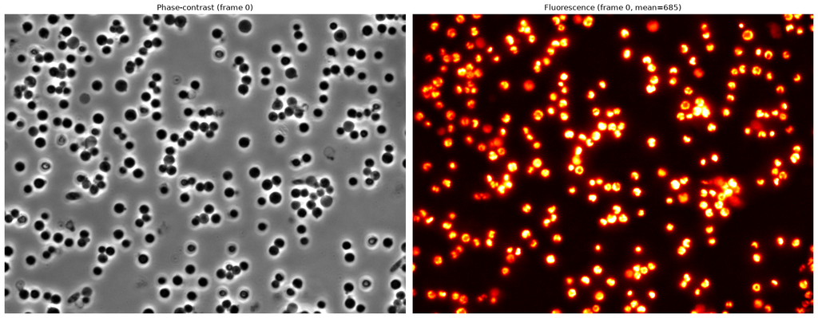

## 3. Fluorescence Quantification and Dynamics

Measures fluorescence intensity and distribution metrics within each phase-contrast cell mask. Metrics per cell per frame:

| Metric | Description |
| --- | --- |
| mean/total/min/max intensity | Basic intensity statistics |
| CV (std/mean) | Nucleoid heterogeneity — high = concentrated, low = dispersed |
| nNRM (KS statistic) | Non-normality of pixel distribution (Gough et al. 2014) |
| skewness, kurtosis | Distribution shape descriptors |

```
Fluorescence measurements: 4994 rows
Matched 4961/4961 detections (100.0%) with fluorescence
Median fluorescence intensity per track: 2034
Median CV per track: 0.465
Median nNRM per track: 0.097
```

```
Nucleoid distribution: 4961/4961 cell-frames measured
```

### 3.1 Population mean fluorescence per frame

[interactive chart not shown]

```
Frame 0 mean fluorescence: 2750
Frame 30 mean fluorescence: 1967
Change: 0.72x
```

*Source: `tracked_cells.csv`*

### 3.2a Relative fluorescence F(t)/F(0)

Same frame-0 cohort used for swelling analysis. Shows how fluorescence changes relative to each cell's initial value. Disappeared vs survived split reveals whether fluorescence predicts cell fate.

[interactive chart not shown]

```
Final F(t)/F(0): 0.769 +/- 0.042
Cells contributing at final frame: 40
```

*Source: `tracked_cells.csv`*

### 3.2b Relative fluorescence F(t)/F(0) vs. normalized lifespan, by fate

Companion to §1.6c — same three panels for fluorescence.

[interactive chart not shown]

*Sources: `tracked_cells.csv`, `track_statistics.csv`*

### 3.3 Fluorescence vs. swelling correlation

Does fluorescence intensity track with cell volume? Each point is one cell at one frame. A positive correlation suggests fluorescence scales with cell size (membrane or cytoplasmic stain); no correlation suggests a localized signal (e.g., nuclear).

[interactive chart not shown]

*Source: `tracked_cells.csv`*

### 3.4a Nucleoid heterogeneity: CV dynamics

CV (coefficient of variation $= \text{std}/\text{mean}$ of pixel intensities within each cell mask) measures nucleoid spatial concentration. High CV = bright nucleoid spots on a dark cytoplasmic background (intact, concentrated). Low CV = more uniform distribution (dispersed nucleoid).

Three views: population mean vs. sucrose concentration, lifespan-normalized (all tracks aligned to $[0,1]$), and disappeared vs. survived across sucrose concentrations.

[interactive chart not shown]

*Sources: `tracked_cells.csv`, `track_statistics.csv`*

### 3.4b Nucleoid edge-distance dynamics

Mean distance of suprathreshold fluorescence pixels from the cell-mask edge, normalized by R/3 (the expected mean-edge-distance for points uniformly distributed inside a circle of radius R). Values > 1 ⇒ pixels clustered toward the center; values < 1 ⇒ pixels at the periphery ("horseshoe"). Approaches 1 as the nucleoid disperses with swelling.

[interactive chart not shown]

*Sources: `tracked_cells.csv`, `track_statistics.csv`*

### 3.5a Non-Normality Index (nNRM) dynamics

nNRM = Kolmogorov-Smirnov statistic comparing pixel intensity distribution against a Gaussian with matching mean and std (Gough et al. 2014, PLOS ONE). Range [0, 1]: 0 = Gaussian, 1 = maximally non-Gaussian. Complements CV — CV measures spread, nNRM measures distribution shape. A high nNRM indicates distinct subpopulations within the cell mask (bright nucleoid vs dark cytoplasm).

[interactive chart not shown]

*Sources: `tracked_cells.csv`, `track_statistics.csv`*

### 3.5b Nucleoid spatial $\sigma$ dynamics

$\sigma$ of the 2D intensity-weighted spatial distribution of suprathreshold pixels (mean of eigenvalues of the weighted covariance), normalized by the cell's pixel-space $R$. Captures dispersion: small $\sigma \Rightarrow$ tight cluster; large $\sigma \Rightarrow$ spread across the cell.

[interactive chart not shown]

*Sources: `tracked_cells.csv`, `track_statistics.csv`*

### 3.5c Peri/core asymmetry dynamics

- **positive** → edge-clustered (expanded / donut-shaped nucleoid),
- **negative** → center-clustered (compacted nucleoid),
- **0** → radially uniform.

[interactive chart not shown]

*Sources: `tracked_cells.csv`, `track_statistics.csv`*

### 3.5d Peri/core asymmetry aligned to phase disappearance

Per-cell trajectory of `peri_core_asymmetry` in the window `[-FLUOR_ALIGN_WINDOW, 0]` frames before each disappeared cell's last detection. Complements §3.5c by removing the averaging-across-frames artifact: cells caught at absolute frame $N$ are at different stages of their own life cycle, so a per-frame median smears the trajectory. Aligning by offset from last-detected frame puts every cell on the same timeline relative to burst.

- **Left panel:** individual trajectories (thin blue), median + IQR band across cells. Shows whether initial donut/sparse phenotypes converge to a common pre-burst state.
- **Right panel:** baseline (offset $-N$) vs. last-frame (offset $0$) scatter, one dot per cell. Points off the diagonal indicate a transformation between initial and pre-burst states.

[interactive chart not shown]

```
Aligned 189 disappeared tracks (window=-5..0)
  offset -5: median asymmetry = -0.040
  offset -4: median asymmetry = -0.042
  offset -3: median asymmetry = -0.043
  offset -2: median asymmetry = -0.037
  offset -1: median asymmetry = -0.043
  offset +0: median asymmetry = -0.040
```

*Source: `peri_core_alignment.csv`*

### 3.5e Max-Intensity Ring Radius dynamics ($r_{\max} / R$)

Normalized radial position ($r_{\max}/R$) of the concentric ring exhibiting the peak mean fluorescence intensity within each cell, bounded in $[0, 1]$:

- **High ($r_{\max}/R \approx 0.5\text{–}0.7$):** Control (horseshoe/ring) — central depression with peak intensity in the peripheral arc.
- **Low ($r_{\max}/R \to 0$):** Compacted — peak intensity concentrated at the geometric center of the nucleoid.
- **Intermediate:** Expanded — fluorescence dispersed broadly across intermediate rings.

Three views: population mean vs. sucrose concentration, lifespan-normalized trajectory split by fate, and disappeared vs. survived across sucrose concentrations.

[interactive chart not shown]

*Sources: `tracked_cells.csv`, `track_statistics.csv`*

### 3.5f Distribution of Max-Intensity Ring Radius: Frame 0 vs. Pre-Burst

Side-by-side histograms (sharing identical axes and binning) comparing the distribution of the Max-Intensity Normalized Radius ($r_{\max}/R$) among bursting tracks (`disappeared == True`) at baseline (`Frame 0`) versus each cell's final tracked frame prior to lysis (`Pre-Burst Frame`). Filtering both distributions to the bursting cohort illustrates how peak nucleoid fluorescence shifts inward toward the geometric center ($r/R \to 0$) prior to membrane rupture.

[interactive chart not shown]

*Sources: `ring_profiles.csv`, `track_statistics.csv`*

### 3.5g Radial Intensity Profile

This plot visualizes the average fluorescence intensity as a function of the normalized physical cell radius ($r/R$). The cell is divided into 15 concentric radial bins, where $0.0$ represents the geometric center and $1.0$ represents the equivalent cell boundary. Profiles are shown at baseline (`Frame 0`) and at `split_frame` (`Frame 16`) to capture radial redistribution as osmotic swelling progresses.

**Expected Morphotype Signatures:**

- **Compacted:** Exhibits a sharp peak near the center ($r/R \approx 0$) that rapidly decays toward the periphery.
- **Control (Horseshoe / Ring):** Displays a central depression (the "hole") with peak intensity in the intermediate/peripheral rings ($r/R \approx 0.5\text{–}0.7$).
- **Expanded:** Shows a broader, flatter distribution of intensity spread across multiple radial bins.

*Note: The solid line represents the mean intensity across all cells in the specified frame, and the shaded region indicates the 95% confidence interval.*

[interactive chart not shown]

*Source: `ring_profiles.csv`*

[interactive chart not shown]

*Source: `ring_profiles.csv`*

### 3.5h Subpopulation Analysis: Bursting Cells with Mid-Radius Peaks ($0.2 \le r_{\text{norm}} \le 0.8$)

To investigate internal structural rearrangements prior to osmotic lysis, we isolate bursting cells (`track_stats["disappeared"] == True`) whose baseline (`Frame 0`) maximum radial intensity falls within the normalized radius range of $0.2$ to $0.8$.

**Analysis Workflow:**

1. **Isolate Bursting Cohort:** Filter `ring_profiles_df` for `track_id`s marked as `disappeared == True` in `track_stats` and identify their final tracked frame (`pre_burst_frame`).
2. **Filter by Max-Intensity Radius:** Select bursting tracks whose `Frame 0` peak intensity radius satisfies $0.2 \le r_{\max}/R \le 0.8$.
3. **Subpopulation Radial Profiles & Sucrose Dynamics:**
   - **Graph 1:** Mean radial intensity profile ($\pm 1\text{ SD}$) at Frame 0.
   - **Graph 2:** Mean radial intensity profile ($\pm 1\text{ SD}$) at the Pre-Burst Frame.
   - **Graph 3:** Direct overlay comparing the mean profiles of Frame 0 and Pre-Burst.
   - **Graph 4:** Population mean Max-Intensity Ring Radius ($\pm 1\text{ SEM}$) vs. Sucrose concentration (%) for this subpopulation (analogous to the left panel in §3.5e).

```
Total bursting tracks: 210
Bursting cells with Frame 0 max intensity between 0.2 and 0.8: 73
```

[interactive chart not shown]

*Sources: `ring_profiles.csv`, `track_statistics.csv`, `tracked_cells.csv`*

### 3.6 Fluorescence dynamics around phase disappearance

Fluorescence loss is rarely instantaneous and rarely aligned with the phase mask vanishing — DNA exits through membrane pores more slowly than proteins, and the lysis itself can take multiple frames. To make this visible, for each `disappeared` cell we align its mean intensity to its last phase-detection frame and plot the ±`FLUOR_ALIGN_WINDOW` frames around that anchor.

Post-disappearance frames (offset > 0) use the cell's **final phase mask** to integrate fluorescence — the cell's last known ROI applied to subsequent fluorescence frames.

[interactive chart not shown]

```
Aligned 189 disappeared tracks (window=+/-5)
  offset -5: median F_norm = 1.000
  offset -4: median F_norm = 0.956
  offset -3: median F_norm = 0.928
  offset -2: median F_norm = 0.918
  offset -1: median F_norm = 0.851
  offset +0: median F_norm = 0.789
  offset +1: median F_norm = 0.217
  offset +2: median F_norm = 0.134
  offset +3: median F_norm = 0.111
  offset +4: median F_norm = 0.102
  offset +5: median F_norm = 0.091
```

*Source: `fluorescence_alignment.csv`*

### 3.7 Fluorescence concentration (dilution-corrected)

Raw fluorescence intensity confounds true signal changes with dilution from cell swelling — a cell that doubles in volume halves its concentration even if total fluorophore content stays constant. Fluorescence concentration (`total_intensity / volume`) corrects for this, revealing whether fluorescence changes are biological or geometric.

```
Fluorescence concentration: 4961/4961 cells computed
```

[interactive chart not shown]

```
Frame 0 mean concentration: 451011.587
Frame 30 mean concentration: 261309.480
Change: 0.58x
```

*Source: `tracked_cells.csv`*

### 3.8 Surface-area-to-volume ratio

SA:V ratio is a proxy for membrane mechanical stress. As cells swell (volume increases faster than surface area for a sphere), SA:V decreases — the membrane must stretch to accommodate the growing volume. Lower SA:V may indicate cells closer to their mechanical rupture threshold.

```
SA:V ratio: 4961/4961 cells computed
Median SA:V at frame 0: 2.6853
```

[interactive chart not shown]

```
SA:V at frame 0: 2.7344
SA:V at frame 30: 2.2230
Median SA:V at death: 2.2989
Median SA:V at end (survived): 2.1877
```

*Sources: `tracked_cells.csv`, `track_statistics.csv`*

### 3.9 Pre-burst fluorescence behavior

Does fluorescence change in the frames immediately before a cell disappears? For each disappeared track, fits a linear trend to mean fluorescence intensity in a 5-frame window before the last detection. A positive slope with intensity exceeding baseline indicates a pre-burst "spike" — possible membrane permeabilization allowing dye influx before final rupture.

```
Pre-burst fluorescence (5-frame window):
  Tracks with pre-burst spike: 18/210 (9%)
```

[interactive chart not shown]

```
Median pre-burst slope: -70.80
Cells with pre-burst spike: 18/210
```

*Sources: `tracked_cells.csv`, `track_statistics.csv`*

### 3.10 Cell fate prediction from frame-0 features

Can we predict which cells will die just from their appearance at frame 0? Two complementary tests on the **frame-0 cohort** (cells visible at `frame == 0`, labelled by their eventual `disappeared` flag from `track_statistics.csv`):

The Mann-Whitney table tests each feature in isolation; the logistic regression asks whether the five together can rank cells by death probability (ROC curve + feature importance).

**Related views of the same question, elsewhere in the report:**

- §3.12 Initial fluorescence features vs. lifespan — same frame-0 features, but plotted against the *continuous* lifetime variable with Spearman rho. Mann-Whitney here, Spearman there.
- §1.6b Swelling extent vs. initial cell size and survival — initial volume vs. eventual fate (V(0) split by survived/disappeared).

```
Frame-0 features by fate (Mann-Whitney U, two-sided):
  Cohort: 40 survived, 184 died
   area: median 4.148 (surv) vs 3.786 (died) [↓ died], U=2838, p=2.34e-02
     cv: median 0.464 (surv) vs 0.489 (died) [↑ died], U=4138, p=2.18e-01
   nnrm: median 0.086 (surv) vs 0.094 (died) [↑ died], U=4007, p=3.79e-01
  mean_edge_distance_norm: median 1.537 (surv) vs 1.548 (died) [↑ died], U=4084, p=2.77e-01
  gaussian_sigma_norm: median 0.349 (surv) vs 0.334 (died) [↓ died], U=3033, p=8.18e-02
```

|  | feature | n_survived | n_died | median_survived | median_died | U | p_value |
| --- | --- | --- | --- | --- | --- | --- | --- |
| 0 | area | 40 | 184 | 4.147769 | 3.785827 | 2837.5 | 0.023414 |
| 1 | cv | 40 | 184 | 0.464056 | 0.488856 | 4138.0 | 0.218118 |
| 2 | nnrm | 40 | 184 | 0.085757 | 0.093509 | 4007.0 | 0.379451 |
| 3 | mean_edge_distance_norm | 40 | 184 | 1.536549 | 1.547919 | 4084.0 | 0.277397 |
| 4 | gaussian_sigma_norm | 40 | 184 | 0.348682 | 0.334457 | 3033.0 | 0.081803 |

```
Fate prediction (LOO cross-validation, n=224):
  AUC: 0.549
  Accuracy: 82.1%
  Died: 184, Survived: 40
  Feature importance (z-scored coefficients):
    area: -0.324 (↓ death)
    cv: +0.130 (↑ death)
    nnrm: -0.148 (↓ death)
    mean_edge_distance_norm: -0.012 (↓ death)
    gaussian_sigma_norm: -0.235 (↓ death)
  Per-class performance (probability threshold 0.5):
    survived     (n= 40): precision=0.000, recall=0.000, f1=0.000
    disappeared  (n=184): precision=0.821, recall=1.000, f1=0.902
  Confusion matrix (rows = actual, cols = predicted):
                              pred: survived  pred: disappeared
    actual: survived                0            40
    actual: disappeared             0           184
Fate prediction (LOO cross-validation, n=224):
  AUC: 0.495
  Accuracy: 81.7%
  Died: 184, Survived: 40
  Feature importance (z-scored coefficients):
    cv: -0.093 (↓ death)
    nnrm: -0.118 (↓ death)
    mean_edge_distance_norm: -0.116 (↓ death)
    gaussian_sigma_norm: -0.504 (↓ death)
  Per-class performance (probability threshold 0.5):
    survived     (n= 40): precision=0.000, recall=0.000, f1=0.000
    disappeared  (n=184): precision=0.821, recall=0.995, f1=0.899
  Confusion matrix (rows = actual, cols = predicted):
                              pred: survived  pred: disappeared
    actual: survived                0            40
    actual: disappeared             1           183
```

[interactive chart not shown]

*Sources: `fate_predictions.csv`, `fate_prediction_summary.csv`*

```
Feature-set comparison:
                        full (5)   no-area (4)
  AUC                   0.549      0.495
  Accuracy              0.821      0.817
  Recall (survived)     0.000      0.000
  Recall (disappeared)  1.000      0.995
  F1 (survived)         0.000      0.000
  F1 (disappeared)      0.902      0.899
  (differences small; full feature set remains the default)
```

### 3.11 Nucleus persistence after cell lysis

Do fluorescent nuclei (DNA) survive as discrete objects after the cell membrane ruptures? To test this, we independently segment the fluorescence channel with Cellpose and compare object counts frame-by-frame against phase-contrast cells.

If nuclei persist after lysis, fluorescence counts should decline slower than phase counts (growing offset). If they disperse immediately, both should decline in parallel (constant offset).

```
Phase cells lost (first to last frame): 198
Fluor nuclei lost (first to last frame): 193
Difference std across frames: 7.8

Conclusion: Phase cells and fluorescent nuclei disappear at the same rate. DNA signal does NOT persist as a discrete object after cell lysis — the fluorescent material disperses upon membrane rupture.
```

[interactive chart not shown]

```
Phase vs fluor count: Pearson r = 0.995, p = 8.22e-31
```

*Sources: `nucleus_persistence.csv`, `nucleus_persistence_summary.csv`*

### 3.12 Initial fluorescence features vs. lifespan

Do cells with different initial fluorescence states live longer? Scatter of frame-0 fluorescence intensity, CV, and nNRM against track lifetime, with Spearman $\rho$ printed per panel. Complements **§3.10 Cell fate prediction**, which tests frame-0 morphological and fluorescence features (`area`, `cv`, `nnrm`, `mean_edge_distance_norm`, `gaussian_sigma_norm`) against the binary `survived`/`died` split via Mann-Whitney U and logistic regression. Lifetime here is the continuous outcome; fate there is the dichotomised one.

Implementation: `plot_initial_features_vs_lifespan()` in `src/cell_analysis/plotting.py`.

[interactive chart not shown]

```
Initial fluorescence vs lifetime: Spearman rho = -0.086, p = 2.01e-01
Initial CV vs lifetime: Spearman rho = -0.105, p = 1.18e-01
Initial nNRM vs lifetime: Spearman rho = -0.181, p = 6.46e-03
```

*Sources: `tracked_cells.csv`, `track_statistics.csv`*

## 4. Export Results

Each CSV is saved inline by the cell that produces it, so the source link under each plot resolves at the moment the plot is rendered. The cell below lists every CSV currently on disk.

| File | Contents |
| --- | --- |
| `tracked_cells.csv` | Per-cell per-frame: morphology (area/volume/SA in µm), volume_rel, fluorescence, fluor_rel, fluor_concentration, sav_ratio |
| `track_statistics.csv` | Per-track summary: lifetime, mean geometry, mean fluorescence (intensity/CV/nNRM), fluorescence-drop frame, pre-burst slope |
| `fluorescence_alignment.csv` | Long-form per-disappeared-cell F(t) trace aligned to last detection frame (offset -window..+window) |
| `peri_core_alignment.csv` | Long-form per-disappeared-cell peri_core_asymmetry aligned to last detection frame (offset -window..0). Delta_from_baseline column = trajectory relative to earliest observation. |
| `frame_diagnostics.csv` | Per-frame detection statistics and gating flags |
| `merge_log.csv` | Track merging audit log (which fragments were absorbed into which tracks) |
| `frame0_fate_comparison.csv` | Per-feature Mann-Whitney U on area/CV/nNRM, survived vs disappeared (frame-0 cohort) |
| `fate_predictions.csv` | Per-cell predicted death probability and class (frame-0 cohort) |
| `fate_prediction_summary.csv` | Single-row: AUC, accuracy, per-feature coefficients |
| `fate_predictions_no_area.csv` | Same as `fate_predictions.csv` but for the 4-feature LR (no `area`) |
| `fate_prediction_summary_no_area.csv` | Single-row: AUC, accuracy, per-class metrics, per-feature coefficients for the no-area model |
| `nucleus_persistence.csv` | Per-frame phase cell vs fluorescence nucleus counts |
| `nucleus_persistence_summary.csv` | Single-row: loss counts, offset CV, conclusion |
| `dropped_frames.csv` | Flagged frames only (created by frame gating if any frames flagged) |

```
Saved 11 files to results/control_experiment/
  fate_prediction_summary.csv
  fate_prediction_summary_no_area.csv
  fate_predictions.csv
  fate_predictions_no_area.csv
  fluorescence_alignment.csv
  frame0_fate_comparison.csv
  nucleus_persistence.csv
  nucleus_persistence_summary.csv
  peri_core_alignment.csv
  track_statistics.csv
  tracked_cells.csv
```

## 5. Export HTML Report

Saves the notebook to disk and exports a self-contained HTML copy to `results/<RUN_NAME>/report.html`. Set `EXPORT_HTML = False` (top of notebook) to skip. The CLI runner (`scripts/run_experiment.py`) uses the same exporter, so interactive and CLI reports stay in sync.

HTML report saved: ..\results\control_experiment\analysis\report.html